© Bản quyền thuộc về Quantopian Inc.  
© Bản quyền sửa đổi thuộc về AI Cafe¹  
Giấy phép [Creative Commons Attribution 4.0](https://creativecommons.org/licenses/by/4.0/legalcode).  
[Khuyến cáo](https://aicafe.one/khuyen-cao/)

# Sự không ổn định của mô hình hồi quy

By Evgenia "Jenny" Nitishinskaya and Delaney Granizo-Mackenzie. Algorithms by David Edwards.

Edited by AI Cafe¹

Phân tích hồi quy cho phép chúng ta ước lượng các hệ số trong một hàm mà tương đối liên quan đến nhiều tập dữ liệu. Chúng ta giả thuyết một dạng cụ thể cho hàm này và sau đó tìm các hệ số phù hợp với dữ liệu, làm việc dưới giả định rằng những sai lệch so với mô hình có thể được coi là nhiễu.

Khi xây dựng một mô hình như vậy, chúng ta chấp nhận rằng nó không thể dự đoán chính xác biến phụ thuộc. Tại đây, chúng ta muốn đánh giá độ chính xác của mô hình không phải bằng cách nó giải thích biến phụ thuộc tốt như thế nào, mà bằng cách nó *ổn định* như thế nào (tức là, các hệ số hồi quy ổn định ra sao) trên đến dữ liệu mẫu của chúng ta. Cuối cùng, nếu một mô hình thực sự là một sự phù hợp tốt, nó nên tách biệt được hai nửa ngẫu nhiên của tập dữ liệu mà chúng ta mô hình hóa riêng biệt. Ngược lại, chúng ta không thể giả định rằng mô hình không chỉ là một sản phẩm của mẫu dữ liệu cụ thể mà chúng ta đã chọn, hoặc rằng nó sẽ dự đoán các điểm dữ liệu mới.

Chúng ta sẽ sử dụng hồi quy tuyến tính ở đây để minh họa, nhưng những cân nhắc tương tự áp dụng cho tất cả các mô hình hồi quy. Dưới đây, chúng ta định nghĩa một hàm wrapper cho hồi quy tuyến tính từ `statsmodels` để có thể sử dụng sau này.

```python
import numpy as np
import pandas as pd
from statsmodels import regression, stats
import statsmodels.api as sm
import matplotlib.pyplot as plt
import scipy as sp

def linreg(X,Y):
    # Running the linear regression
    x = sm.add_constant(X) # Add a row of 1's so that our model has a constant term
    model = regression.linear_model.OLS(Y, x).fit()
    return model.params[0], model.params[1] # Return the coefficients of the linear model
```

## Sai lệch nhiễu

Mẫu dữ liệu mà chúng ta chọn ảnh hưởng đến mô hình được tạo ra, và nhiễu phân phối không đều có thể dẫn đến một mô hình không chính xác. Dưới đây, chúng ta lấy mẫu từ một phân phối chuẩn, nhưng vì chúng ta không có nhiều điểm dữ liệu, chúng ta nhận được một thiên lệch đáng kể. Nếu chúng ta thực hiện nhiều phép đo hơn, cả hai hệ số hồi quy sẽ di chuyển về phía không.

```
Slope: 0.009072503822685526 Intercept: -0.40207744085303815
```

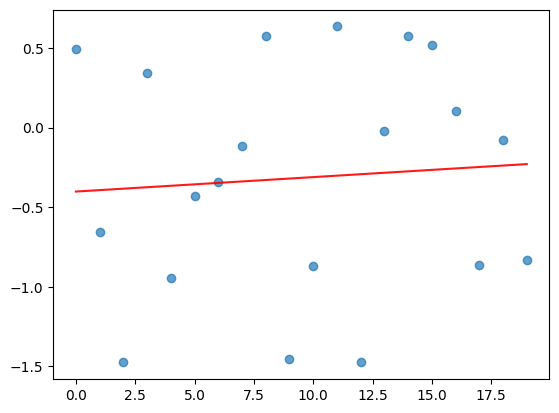

```python
# Draw observations from normal distribution
np.random.seed(107) # Fix seed for random number generation
rand = np.random.randn(20)

# Conduct linear regression on the ordered list of observations
xs = np.arange(20)
a, b = linreg(xs, rand)
print('Slope:', b, 'Intercept:', a)

# Plot the raw data and the regression line
plt.scatter(xs, rand, alpha=0.7)
Y_hat = xs * b + a
plt.plot(xs, Y_hat, 'r', alpha=0.9);
```

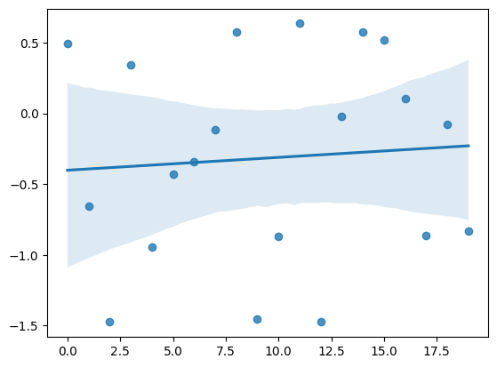

```python
import seaborn

seaborn.regplot(x=xs, y=rand);
```

```
Slope: -0.0005693423631053362 Intercept: 0.009011767319021952
```

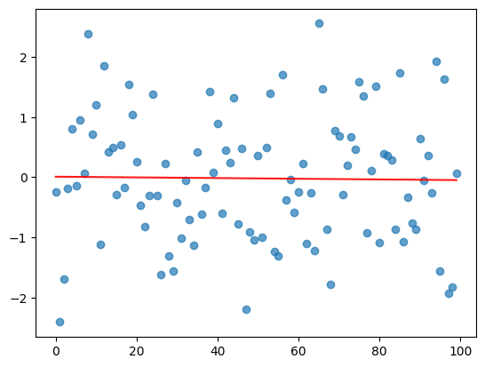

```python
# Draw more observations
rand2 = np.random.randn(100)

# Conduct linear regression on the ordered list of observations
xs2 = np.arange(100)
a2, b2 = linreg(xs2, rand2)
print('Slope:', b2, 'Intercept:', a2)

# Plot the raw data and the regression line
plt.scatter(xs2, rand2, alpha=0.7)
Y_hat2 = xs2 * b2 + a2
plt.plot(xs2, Y_hat2, 'r', alpha=0.9);
```

Phân tích hồi quy rất nhạy cảm với các điểm ngoại lai. Đôi khi những điểm ngoại lai này chứa thông tin, trong trường hợp đó, chúng ta muốn xem xét chúng; tuy nhiên, trong những trường hợp như trên, chúng có thể chỉ là nhiễu ngẫu nhiên. Mặc dù chúng ta thường có nhiều điểm dữ liệu hơn so với ví dụ trên, nhưng chúng ta có thể gặp (ví dụ) sự dao động theo tuần hoặc tháng, điều này sau đó có thể thay đổi đáng kể các hệ số hồi quy.

## Thay đổi chế độ (Regime changes)

```python
# Cài thư viện lấy dữ liệu miễn phí
!curl -fsSLO https://raw.githubusercontent.com/algo-stocks/data/master/data.py
```

```python
from data import get_prices

start = '2020-04-01'
end = '2023-01-01'

prices = get_prices('VNINDEX', start_date=start, end_date=end)
```

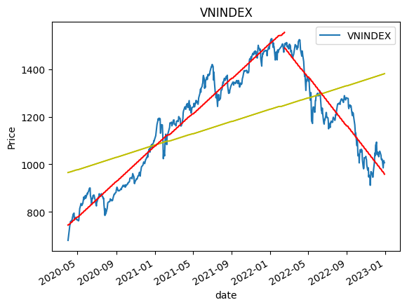

```python
# Manually set the point where we think a structural break occurs
breakpoint = 470
xs = np.arange(len(prices))
xs2 = np.arange(breakpoint)
xs3 = np.arange(len(prices) - breakpoint)

# Perform linear regressions on the full data set, the data up to the breakpoint, and the data after
a, b = linreg(xs, prices.values)
a2, b2 = linreg(xs2, prices[:breakpoint].values)
a3, b3 = linreg(xs3, prices[breakpoint:].values)

Y_hat = pd.Series(xs * b + a, index=prices.index)
Y_hat2 = pd.Series(xs2 * b2 + a2, index=prices.index[:breakpoint])
Y_hat3 = pd.Series(xs3 * b3 + a3, index=prices.index[breakpoint:])

# Plot the raw data
prices.plot()
Y_hat.plot(color='y')
Y_hat2.plot(color='r')
Y_hat3.plot(color='r')
plt.title('VNINDEX')
plt.ylabel('Price');
```

Tất nhiên, càng phân chia tập dữ liệu của chúng ta thành nhiều phần, chúng ta càng có thể phù hợp chính xác hơn với nó. Điều quan trọng là tránh việc phù hợp với nhiễu, điều mà luôn dao động và không có tính dự đoán. Chúng ta có thể kiểm tra sự tồn tại của một sự đứt gãy cấu trúc, tại một điểm cụ thể mà chúng ta đã xác định hoặc trên tổng thể. Dưới đây, chúng ta sử dụng một bài kiểm tra từ `statsmodels` để tính toán xác suất quan sát dữ liệu nếu không có điểm đứt gãy.

```python
stats.diagnostic.breaks_cusumolsresid(
    regression.linear_model.OLS(prices, sm.add_constant(xs)).fit().resid
)[1]
```

```
np.float64(9.803120632815442e-35)
```

Xác suất này rất nhỏ, có nghĩa là nếu không có sự đứt gãy thì khả năng chúng ta quan sát được dữ liệu này theo mô hình là gần như không sảy ra

## Đa cộng tuyến

Trên đây, chúng ta chỉ xem xét hồi quy của một biến phụ thuộc so với một biến độc lập. Tuy nhiên, chúng ta cũng có thể có nhiều biến độc lập. Điều này dẫn đến sự không ổn định nếu các biến độc lập có mối tương quan cao.

Hãy tưởng tượng chúng ta đang sử dụng hai biến độc lập, $X_1$ và $X_2$, mà có tương quan rất cao với nhau. Khi đó, các hệ số có thể thay đổi một cách đáng kể nếu chúng ta thêm một quan sát mới mà được giải thích tốt hơn bởi một trong hai biến hơn là biến kia. Trong trường hợp cực đoan, nếu $X_1 = X_2$, thì sự lựa chọn các hệ số sẽ phụ thuộc vào thuật toán hồi quy tuyến tính cụ thể.

Dưới đây, chúng ta thực hiện một hồi quy tuyến tính đa biến trong đó các biến độc lập có mối tương quan cao. Nếu chúng ta lấy khoảng thời gian mẫu từ 2023-01-01 đến 2025-01-01, thì các hệ số xấp xỉ là 3.34 và 2.67. Nhưng nếu chúng ta mở rộng khoảng thời gian đến 2025-04-01, các hệ số trở thành xấp xỉ 3.63 và 2.9.

```
Constant: -183.43014359975245 MLR beta to BID: 3.343177225161816 MLR beta to VCB 2.671825636086167
```

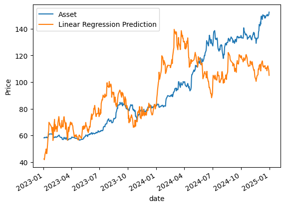

```python
start = '2023-01-01'
end = '2025-01-01'

prices = get_prices('FPT', 'BID', 'VCB', start_date=start, end_date=end)

b1 = prices['BID']
b2 = prices['VCB']
asset = prices['FPT']

mlr = regression.linear_model.OLS(asset, sm.add_constant(np.column_stack((b1, b2)))).fit()
prediction = mlr.params.iloc[0] + mlr.params.iloc[1]*b1 + mlr.params.iloc[2]*b2
print('Constant:', mlr.params.iloc[0], 'MLR beta to BID:', mlr.params.iloc[1], 'MLR beta to VCB', mlr.params.iloc[2])

# Plot the asset pricing data and the regression model prediction, just for fun
asset.plot()
prediction.plot();
plt.ylabel('Price')
plt.legend(['Asset', 'Linear Regression Prediction']);
```

```
Constant: -205.50204985773877 MLR beta to BID: 3.6325685540098083 MLR beta to VCB 2.9055250667149157
```

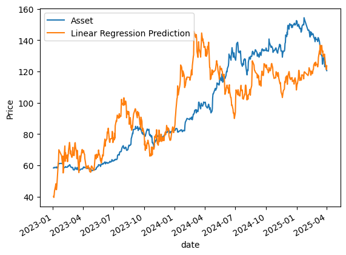

```python
start = '2023-01-01'
end = '2025-04-01'

prices = get_prices('FPT', 'BID', 'VCB', start_date=start, end_date=end)

b1 = prices['BID']
b2 = prices['VCB']
asset = prices['FPT']

mlr = regression.linear_model.OLS(asset, sm.add_constant(np.column_stack((b1, b2)))).fit()
prediction = mlr.params.iloc[0] + mlr.params.iloc[1]*b1 + mlr.params.iloc[2]*b2
print('Constant:', mlr.params.iloc[0], 'MLR beta to BID:', mlr.params.iloc[1], 'MLR beta to VCB', mlr.params.iloc[2])

# Plot the asset pricing data and the regression model prediction, just for fun
asset.plot()
prediction.plot();
plt.ylabel('Price')
plt.legend(['Asset', 'Linear Regression Prediction']);
```

Chúng ta có thể kiểm tra xem các biến độc lập của mình có tương quan với nhau hay không bằng cách tính toán hệ số tương quan của chúng. Số này luôn nằm trong khoảng từ -1 đến 1, và giá trị 1 có nghĩa là hai biến này có mối tương quan hoàn hảo.

```python
# Compute Pearson correlation coefficient
sp.stats.pearsonr(b1,b2)[0] # Second return value is p-value
```

```
np.float64(0.7409577838883372)
```

*Lưu ý: Tài liệu này mang tính chất chia sẻ kiến thức khoa học dữ liệu. Các mã chứng khoán xuất hiện trong tài liệu chỉ mang tính chất minh hoạ, không khuyến nghị đầu tư. Chúng tôi không chịu trách nhiệm trước mọi rủi ro nào do sử dụng tài liệu này.*